# Projet 1 SY09

## Exercice 1

### Question 1 : Annalyse exploratoire des données

```r
recettes <- read.table('donnees/donnees/recettes-pays.data',header = T,sep = ',',row.names = 1)
```

```r
head(recettes)
```

|  | olive_oil | cayenne | butter | soy_sauce | garlic | ginger | cumin | fish | onion | cilantro | wheat | rice | egg | tomato | scallion | coriander | lime_juice | vegetable_oil | corn | cream | turmeric | sesame_oil | bell_pepper | cinnamon | parsley | lemon_juice | milk | vinegar | wine | … |
| --- | --- | --- | --- | --- | --- | --- | --- | --- | --- | --- | --- | --- | --- | --- | --- | --- | --- | --- | --- | --- | --- | --- | --- | --- | --- | --- | --- | --- | --- | --- |
| African | 0.52173913 | 0.3565217 | 0.20869565 | 0.008695652 | 0.4956522 | 0.260869565 | 0.426086957 | 0.07826087 | 0.5304348 | 0.243478261 | 0.2608696 | 0.10434783 | 0.2000000 | 0.25217391 | 0.05217391 | 0.27826087 | 0.04347826 | 0.1739130 | 0.03478261 | 0.03478261 | 0.156521739 | 0.000000000 | 0.31304348 | 0.28695652 | 0.191304348 | 0.26086957 | 0.08695652 | 0.05217391 | 0.017391304 | … |
| American | 0.30312751 | 0.1309142 | 0.44486768 | 0.022654370 | 0.2540096 | 0.078989575 | 0.058139535 | 0.04029671 | 0.2514034 | 0.057939054 | 0.3155573 | 0.03227747 | 0.3484362 | 0.13331997 | 0.07217322 | 0.02786688 | 0.04550922 | 0.1856455 | 0.10344828 | 0.24819567 | 0.015236568 | 0.010224539 | 0.09643144 | 0.09623095 | 0.131916600 | 0.15296712 | 0.18885325 | 0.15817963 | 0.029470730 | … |
| Asian | 0.06632653 | 0.2933673 | 0.05867347 | 0.500000000 | 0.4804422 | 0.489795918 | 0.083333333 | 0.19387755 | 0.1420068 | 0.207482993 | 0.0952381 | 0.40986395 | 0.1369048 | 0.05782313 | 0.38520408 | 0.13350340 | 0.16581633 | 0.3622449 | 0.05017007 | 0.03571429 | 0.079931973 | 0.301870748 | 0.13180272 | 0.02891156 | 0.014455782 | 0.05442177 | 0.02380952 | 0.33758503 | 0.126700680 | … |
| Cajun_Creole | 0.28767123 | 0.5616438 | 0.36301370 | 0.020547945 | 0.4863014 | 0.047945205 | 0.034246575 | 0.04794521 | 0.6986301 | 0.006849315 | 0.3082192 | 0.26027397 | 0.2534247 | 0.31506849 | 0.28767123 | 0.01369863 | 0.02739726 | 0.3424658 | 0.10273973 | 0.12328767 | 0.000000000 | 0.006849315 | 0.34246575 | 0.04109589 | 0.191780822 | 0.11643836 | 0.08219178 | 0.21917808 | 0.191780822 | … |
| Central_SouthAmerican | 0.31120332 | 0.5186722 | 0.23236515 | 0.012448133 | 0.5684647 | 0.008298755 | 0.240663900 | 0.03319502 | 0.5435685 | 0.311203320 | 0.1950207 | 0.06224066 | 0.2116183 | 0.41493776 | 0.14107884 | 0.04979253 | 0.17012448 | 0.2074689 | 0.32780083 | 0.18257261 | 0.008298755 | 0.004149378 | 0.16597510 | 0.11203320 | 0.107883817 | 0.03734440 | 0.14937759 | 0.17012448 | 0.008298755 | … |
| Chinese | 0.01327434 | 0.2168142 | 0.04867257 | 0.663716814 | 0.5132743 | 0.619469027 | 0.008849558 | 0.05752212 | 0.1061947 | 0.163716814 | 0.1283186 | 0.38053097 | 0.1548673 | 0.03539823 | 0.47345133 | 0.03982301 | 0.02212389 | 0.3008850 | 0.08407080 | 0.02212389 | 0.008849558 | 0.420353982 | 0.07964602 | 0.03097345 | 0.004424779 | 0.01327434 | 0.01769912 | 0.29203540 | 0.300884956 | … |

> Ces données sont faites de valeures comprises entre 0 et 1 avec en individu des origines géographiques et en variables ce qui s’apparente à des proportions d’utilisation. L’objecti de ce travail va être d’étudier les groupements possibles entre les individus.

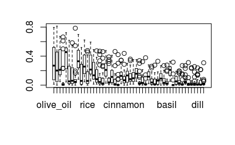

```r
boxplot(recettes)
```

> Certains aliments sont globalement bien plus utilisés que d’autres.

```r
head(as.data.frame(cor(recettes)))
```

|  | olive_oil | cayenne | butter | soy_sauce | garlic | ginger | cumin | fish | onion | cilantro | wheat | rice | egg | tomato | scallion | coriander | lime_juice | vegetable_oil | corn | cream | turmeric | sesame_oil | bell_pepper | cinnamon | parsley | lemon_juice | milk | vinegar | wine | … |
| --- | --- | --- | --- | --- | --- | --- | --- | --- | --- | --- | --- | --- | --- | --- | --- | --- | --- | --- | --- | --- | --- | --- | --- | --- | --- | --- | --- | --- | --- | --- |
| olive_oil | 1.00000000 | -0.01491316 | -0.2431967 | -0.45245972 | 0.3536007 | -0.3925468 | 0.2889344 | -0.2530390 | 0.41508147 | -0.02056793 | -0.0210417 | -0.4197195 | -0.2515218 | 0.6752394 | -0.4299845 | 0.01539997 | -0.2987062 | -0.7567433 | -0.07251210 | -0.2584883 | -0.09908291 | -0.4218781 | 0.52675848 | 0.425232181 | 0.79570781 | 0.72044439 | -0.1757267 | -0.43809185 | -0.33446892 | … |
| cayenne | -0.01491316 | 1.00000000 | -0.5244900 | 0.04340189 | 0.7360336 | 0.1600946 | 0.5320007 | 0.2258874 | 0.57350186 | 0.84543343 | -0.5368325 | 0.2751638 | -0.5958536 | 0.5520620 | 0.4180554 | 0.35206649 | 0.6967234 | 0.4070730 | 0.67004168 | -0.3081181 | 0.28763882 | 0.0416652 | 0.58513111 | -0.041030711 | -0.39722316 | -0.20730295 | -0.4397265 | -0.04484664 | -0.01106269 | … |
| butter | -0.24319666 | -0.52448999 | 1.0000000 | -0.53049816 | -0.7879472 | -0.5472710 | -0.3877538 | -0.4362699 | -0.02845633 | -0.63089379 | 0.8585448 | -0.6239272 | 0.8599843 | -0.3080970 | -0.6117144 | -0.38892367 | -0.5293046 | -0.3064671 | -0.03968489 | 0.8569181 | -0.32445987 | -0.4668187 | -0.42569614 | 0.003758770 | 0.21656325 | -0.07980032 | 0.8671370 | -0.19437863 | -0.37502502 | … |
| soy_sauce | -0.45245972 | 0.04340189 | -0.5304982 | 1.00000000 | 0.1550530 | 0.7946100 | -0.1953340 | 0.3527794 | -0.58308828 | 0.14652444 | -0.5293400 | 0.8315838 | -0.4226791 | -0.4670438 | 0.8642526 | 0.02965227 | 0.2700300 | 0.5372456 | -0.14173636 | -0.4490559 | 0.03017255 | 0.9243978 | -0.14653413 | -0.371856024 | -0.58958336 | -0.37003021 | -0.4799057 | 0.61271960 | 0.84474863 | … |
| garlic | 0.35360074 | 0.73603360 | -0.7879472 | 0.15505303 | 1.0000000 | 0.2338405 | 0.3991841 | 0.4467733 | 0.39050808 | 0.71082829 | -0.7213079 | 0.4084614 | -0.7664973 | 0.5819677 | 0.4357937 | 0.29377859 | 0.6148195 | 0.1310967 | 0.31015734 | -0.6368708 | 0.23385574 | 0.1947963 | 0.62296244 | -0.009841724 | -0.03811401 | 0.01139594 | -0.6116921 | -0.02324860 | 0.06001633 | … |
| ginger | -0.39254681 | 0.16009462 | -0.5472710 | 0.79460998 | 0.2338405 | 1.0000000 | 0.2805713 | 0.3735886 | -0.44378964 | 0.34593545 | -0.5106070 | 0.7645351 | -0.5399659 | -0.4394112 | 0.6903840 | 0.56064990 | 0.2756971 | 0.6052108 | -0.26451942 | -0.5670511 | 0.55917271 | 0.8103566 | 0.02068023 | 0.029996786 | -0.54698687 | -0.15642183 | -0.5459108 | 0.34875118 | 0.56749031 | … |

> Certaines valeurs semblent être fortement corrélées entre elles et d’autres absolument pas. Le gingembre et la sauce Soja ainsi que l’huilde d’olive et le piment de Cayenne l’illustrent bien.

### Question 2

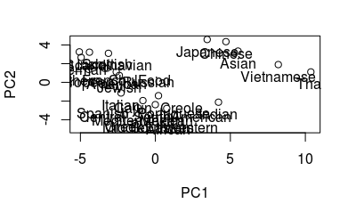

```r
recettes.ACP <- prcomp(recettes,scale. = T)
plot(recettes.ACP$x[,1:2])
text(recettes.ACP$x[,1:2], rownames(recettes), pos = 1)
```

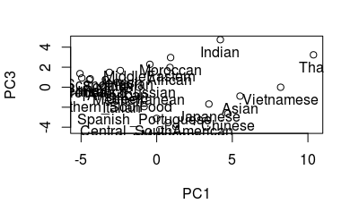

```r
plot(recettes.ACP$x[,c(1,3)])
text(recettes.ACP$x[,c(1,3)], rownames(recettes), pos = 1)
```

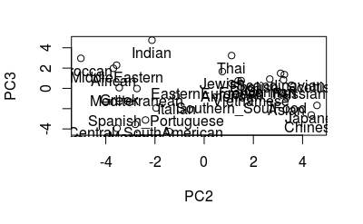

```r
plot(recettes.ACP$x[,2:3])
text(recettes.ACP$x[,2:3], rownames(recettes), pos = 1)
```

> On distingue deux voire trois groupes de manière plus ou moins distincte On pourrait y voir les plats Asiatiques, les plats d’Europe du Nord et les plats méditerranéens confondus avec les plats réputés épicés

### Question 3

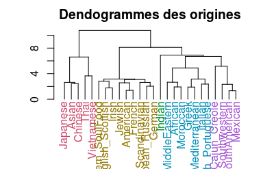

```r
library(dendextend)
recettes.dist <- dist(recettes, method = "manhattan")
recettes.hierarchy <- hclust(recettes.dist)
plot(color_labels(recettes.hierarchy, k = 5), main = "Dendogrammes des origines")
```

> On retrouve les 3 classes décrites avant dans le dendogramme ci-dessus. Le dernier groupe un peu fourre tout a été séparé en des classes plus distinctes

### Question 4

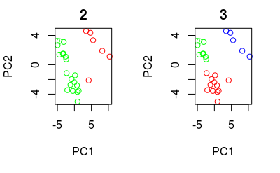

```r
par(mfrow=c(1,2))
recette.kMeans <- list()
for (i in c(2:7)) {
  recetteKMeans <- list()
  for(j in c(1:20)) {
    km <- list(kmeans(recettes, i))
    recetteKMeans <- c(recetteKMeans, km)
  }
  r <- lapply(recetteKMeans,FUN = function(x) {
    x$tot.withinss
  })

  lapply(r,min)
  minIndex <- which.min(unlist(r))

  bestKm <- list(recetteKMeans[[minIndex]])

  recette.kMeans <- c(recette.kMeans, bestKm)
}
for(i in c(2:3)) {
    plot(recettes.ACP$x[1:26,], col=c("red", "green", "blue", "black",     "orange", "purple", "pink")[recette.kMeans[[i - 1]]$cluster], main = i)
}
```

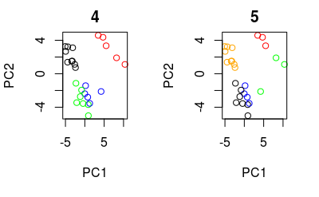

```r
par(mfrow=c(1,2))
for(i in c(4:5)) {
    plot(recettes.ACP$x[1:26,], col=c("red", "green", "blue", "black",     "orange", "purple", "pink")[recette.kMeans[[i - 1]]$cluster], main = i)
}
```

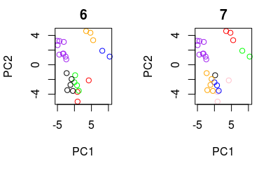

```r
par(mfrow=c(1,2))
for(i in c(6:7)) {
    plot(ACPrecettes$x[1:26,], col=c("red", "green", "blue", "black",     "orange", "purple", "pink")[recetteBestKMeans[[i - 1]]$cluster], main = i)
}
```

> La séparation semble pertinente jusqu’ 3 voire 4 classes. Après, cela semble relever de différences moindres. On a même une classe ne contenant qu’une seule valeure pour une itération avec 7 classes.

### Question 5

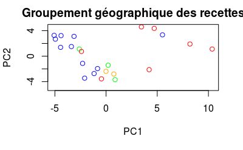

```r
continent <- c(1:26)
continent.cluster <-cbind(recettes, continent)
#ASIA
continent.cluster[c("Asia", "Chinese", "Thai", "Japanese", "Vietnamese", "Jewish", "MiddleEastern", "Indian"), "continent"] <- 1
#AFRICA
continent.cluster[c("African", "Morrocan", "Cajun_Creole"), "continent"] <- 2
#EUROPE
continent.cluster[c("English_Scottish", "Irish", "French", "Scandinavian", "EasternEuropean_Russian", "German", "Greek", "Italian", "Mediterranean", "Spanish_Portuguese", ""), "continent"] <- 3
#NA
continent.cluster[c("America", "Southern_SoolFood", "SouthWestern"), "continent"] <- 4
#SA
continent.cluster[c("Mexican", "Central_SouthAmerican"), "continent"] <- 5
plot(recettes.ACP$x, col=c("red", "green", "blue", "black",     "orange", "purple", "pink" )[continent.cluster[,"continent"]], main = ("Groupement géographique des recettes"))
```

> On obtient des différences notables entre les deux groupements. Cela s’explique facilement, cette representation repose sur une séparation continentale et non culturelle. Une expertise métier serait donc nécessaire pour faire mieux ces groupements. (Bassin Mediterranéen, Asie de L’est …)

### Question 6

```r
recetteEchant <- read.table('donnees/donnees/recettes-echant.data',header = T,sep = ',')

head(recetteEchant)
```

```r
summary(recetteEchant)
```

```
                origin        garlic       olive_oil         butter            egg             onion           wheat
 American          :745   Min.   :0.00   Min.   :0.000   Min.   :0.0000   Min.   :0.0000   Min.   :0.000   Min.   :0.000
 Italian           :250   1st Qu.:0.00   1st Qu.:0.000   1st Qu.:0.0000   1st Qu.:0.0000   1st Qu.:0.000   1st Qu.:0.000
 Asian             :187   Median :0.00   Median :0.000   Median :0.0000   Median :0.0000   Median :0.000   Median :0.000
 French            :157   Mean   :0.35   Mean   :0.336   Mean   :0.3255   Mean   :0.3015   Mean   :0.281   Mean   :0.281
 Mexican           : 86   3rd Qu.:1.00   3rd Qu.:1.000   3rd Qu.:1.0000   3rd Qu.:1.0000   3rd Qu.:1.000   3rd Qu.:1.000
 Spanish_Portuguese: 56   Max.   :1.00   Max.   :1.000   Max.   :1.0000   Max.   :1.0000   Max.   :1.000   Max.   :1.000
 (Other)           :519
  black_pepper    vegetable_oil     tomato          cream           cayenne          vinegar           milk
 Min.   :0.0000   Min.   :0.0   Min.   :0.000   Min.   :0.0000   Min.   :0.0000   Min.   :0.000   Min.   :0.000
 1st Qu.:0.0000   1st Qu.:0.0   1st Qu.:0.000   1st Qu.:0.0000   1st Qu.:0.0000   1st Qu.:0.000   1st Qu.:0.000
 Median :0.0000   Median :0.0   Median :0.000   Median :0.0000   Median :0.0000   Median :0.000   Median :0.000
 Mean   :0.2195   Mean   :0.2   Mean   :0.191   Mean   :0.1805   Mean   :0.1795   Mean   :0.159   Mean   :0.139
 3rd Qu.:0.0000   3rd Qu.:0.0   3rd Qu.:0.000   3rd Qu.:0.0000   3rd Qu.:0.0000   3rd Qu.:0.000   3rd Qu.:0.000
 Max.   :1.0000   Max.   :1.0   Max.   :1.000   Max.   :1.0000   Max.   :1.0000   Max.   :1.000   Max.   :1.000

     ginger         parsley        lemon_juice     bell_pepper        scallion      chicken_broth        pepper
 Min.   :0.000   Min.   :0.0000   Min.   :0.000   Min.   :0.0000   Min.   :0.0000   Min.   :0.0000   Min.   :0.0000
 1st Qu.:0.000   1st Qu.:0.0000   1st Qu.:0.000   1st Qu.:0.0000   1st Qu.:0.0000   1st Qu.:0.0000   1st Qu.:0.0000
 Median :0.000   Median :0.0000   Median :0.000   Median :0.0000   Median :0.0000   Median :0.0000   Median :0.0000
 Mean   :0.134   Mean   :0.1335   Mean   :0.129   Mean   :0.1255   Mean   :0.1165   Mean   :0.1145   Mean   :0.1095
 3rd Qu.:0.000   3rd Qu.:0.0000   3rd Qu.:0.000   3rd Qu.:0.0000   3rd Qu.:0.0000   3rd Qu.:0.0000   3rd Qu.:0.0000
 Max.   :1.000   Max.   :1.0000   Max.   :1.000   Max.   :1.0000   Max.   :1.0000   Max.   :1.0000   Max.   :1.0000

    cilantro        vanilla           corn       cane_molasses        rice            bread           chicken
 Min.   :0.000   Min.   :0.000   Min.   :0.000   Min.   :0.000   Min.   :0.0000   Min.   :0.0000   Min.   :0.000
 1st Qu.:0.000   1st Qu.:0.000   1st Qu.:0.000   1st Qu.:0.000   1st Qu.:0.0000   1st Qu.:0.0000   1st Qu.:0.000
 Median :0.000   Median :0.000   Median :0.000   Median :0.000   Median :0.0000   Median :0.0000   Median :0.000
 Mean   :0.103   Mean   :0.099   Mean   :0.096   Mean   :0.092   Mean   :0.0915   Mean   :0.0915   Mean   :0.088
 3rd Qu.:0.000   3rd Qu.:0.000   3rd Qu.:0.000   3rd Qu.:0.000   3rd Qu.:0.0000   3rd Qu.:0.0000   3rd Qu.:0.000
 Max.   :1.000   Max.   :1.000   Max.   :1.000   Max.   :1.000   Max.   :1.0000   Max.   :1.0000   Max.   :1.000

     cumin         soy_sauce         cinnamon         thyme            fish            cheese        shallot
 Min.   :0.000   Min.   :0.0000   Min.   :0.000   Min.   :0.000   Min.   :0.0000   Min.   :0.00   Min.   :0.000
 1st Qu.:0.000   1st Qu.:0.0000   1st Qu.:0.000   1st Qu.:0.000   1st Qu.:0.0000   1st Qu.:0.00   1st Qu.:0.000
 Median :0.000   Median :0.0000   Median :0.000   Median :0.000   Median :0.0000   Median :0.00   Median :0.000
 Mean   :0.083   Mean   :0.0825   Mean   :0.078   Mean   :0.075   Mean   :0.0745   Mean   :0.07   Mean   :0.069
 3rd Qu.:0.000   3rd Qu.:0.0000   3rd Qu.:0.000   3rd Qu.:0.000   3rd Qu.:0.0000   3rd Qu.:0.00   3rd Qu.:0.000
 Max.   :1.000   Max.   :1.0000   Max.   :1.000   Max.   :1.000   Max.   :1.0000   Max.   :1.00   Max.   :1.000

```

[output cut: 8 more lines]

```
   lime_juice      mustard          milk_fat         potato           celery            wine           cocoa
 Min.   :0.00   Min.   :0.0000   Min.   :0.000   Min.   :0.0000   Min.   :0.0000   Min.   :0.000   Min.   :0.0000
 1st Qu.:0.00   1st Qu.:0.0000   1st Qu.:0.000   1st Qu.:0.0000   1st Qu.:0.0000   1st Qu.:0.000   1st Qu.:0.0000
 Median :0.00   Median :0.0000   Median :0.000   Median :0.0000   Median :0.0000   Median :0.000   Median :0.0000
 Mean   :0.06   Mean   :0.0585   Mean   :0.056   Mean   :0.0545   Mean   :0.0525   Mean   :0.049   Mean   :0.0485
 3rd Qu.:0.00   3rd Qu.:0.0000   3rd Qu.:0.000   3rd Qu.:0.0000   3rd Qu.:0.0000   3rd Qu.:0.000   3rd Qu.:0.0000
 Max.   :1.00   Max.   :1.0000   Max.   :1.000   Max.   :1.0000   Max.   :1.0000   Max.   :1.000   Max.   :1.0000

      mint           honey
 Min.   :0.000   Min.   :0.0000
 1st Qu.:0.000   1st Qu.:0.0000
 Median :0.000   Median :0.0000
 Mean   :0.048   Mean   :0.0465
 3rd Qu.:0.000   3rd Qu.:0.0000
 Max.   :1.000   Max.   :1.0000
```

> Les observations sont composées de 0 et de 1 qui font office de booléen pour savoir si une recette utilise tel ou tel ingrédient. RecetteEchant est donc la source qui a été agrégée sur les origines pour la première partie de l’exercice Attention, il semblerait que quelques origines concentre une grande partie des observations : 745 observations sur 2000 pour les recettes Américaines.

### Question 7

```r
recetteEchant.t <- t(recetteEchant)
#On essaye de coder les variables qualitatives que sont les origines en une matrice de 0 et 1
originMatrix <- matrix(data = 0, nrow = length(unique(factor(recetteEchant$origin))), ncol = length(recetteEchant[,1]))
row.names(x = originMatrix) <-  unique(factor(recetteEchant$origin))
for (i in c(1:length(recetteEchant[,1]))) {
  originMatrix[recetteEchant.t["origin", i], i] <- 1
}
recetteEchant.t <- rbind(recetteEchant.t[2:51,], originMatrix)
for(i in c(1:length(recetteEchant.t[,1]))) {
  for (j in c(1:length(recetteEchant.t[1,])))
    recetteEchant.t[i,j] <- as.numeric(recetteEchant.t[i,j])
}
#Ici on ne prends pas les pays en compte
recetteEchant.t.dist <- dist(recetteEchant.t[1:50,],method = "binary")
```

> L’idée est de prendre la matrice transposée afin d’obtenir un tableau qui pour chaque ingrédient nous dit s’il a été observé lors d’une observation i. Avec cette information on calcul la matrice de distance entre chaque ingrédient. On choisit une distance binaire celle ci étant construite sur des proportion de bit True et non sur une somme. On s’affranchit ainsi des problèmes liés à la sur représentation de certaines régions dans le dataSet de base.

> Ici on perd toute information relative aux origines. Quand on ne supprime pas les origines, on trouve des informations aberrantes comme de grosses distances entre la cuisine japonaise et Asiatique

> On utilise la distance binnaire puisqu’on a des valeurs psuudo booléenne. Cela permet d’avoir des distances entre 0 et 1 ce qui est logique quant à la matrice de départ.

### Question 8

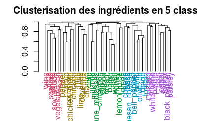

```r
ingredientClusters <- hclust(recetteEchant.t.dist)
plot(color_labels(ingredientClusters, k = 5))
title("Clusterisation des ingrédients en 5 classe")
```

> Ici, on observe une séparation sur 5 classes d’ingrédients. On essaye par la suite la même méthode sur 6 classes :

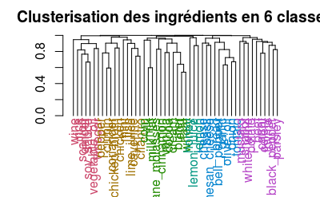

```r
ingredientClusters <- hclust(recetteEchant.t.dist)
plot(color_labels(ingredientClusters, k = 6))
title("Clusterisation des ingrédients en 6 classes")
```

[figure not shown]

```r
par(mfrow=c(1,2))
library(cluster)
recetteEchant.t <- recetteEchant.t[1:50,]
recetteEchant.PAM3 <- cluster::pam(recetteEchant.t.dist,k = 3, metric = "manhattan", diss = T)
cluster::clusplot(as.data.frame(t(recettes)),recetteEchant.PAM3$clustering, main = "Clusterisation des ingrédients en 3 classes")
recetteEchant.PAM5 <- cluster::pam(recetteEchant.t.dist,k = 5, metric = "manhattan", diss = T)
cluster::clusplot(as.data.frame(t(recettes)),recetteEchant.PAM5$clustering, main = "Clusterisation des ingrédients en 5 classes")
```

> Pour en arriver à cette figure, nous avons projeté la clusterisation PAM sur la transposé de la matrice agrégée vue en première partie. Cette transposée permet d’avoir une matrice agrégée sur les ingrédients. On ne peut pas le faire directement sur recetteEchant puisque son dimensionnement ne permet pas d’obtenir suffisemment d’observations pour appliquer princomp.

```r
print(recetteEchant.PAM3$medoids)
```

```
[1] "onion"  "egg"    "ginger"
```

> Les 3 médoides trouvés sont oeuf Oignion et le gingembre

```r
print(recetteEchant.PAM5$medoids)
```

```
[1] "olive_oil" "egg"       "cumin"     "soy_sauce" "celery"
```

> Pour 5 classes, on ne trouve pas les mêmes médoïdes. On peut donc en déduire que les classes d’oignons et gingembre ont été “coupées” en deux.

## Exercice 2

```r
#Ce code est du à un problème d'import de la fonction
distXY <- function(X, Y, M=diag(dim(X)[2]))
{
  X <- as.matrix(X)
  Y <- as.matrix(Y)

  if (!is.matrix(X))
  {
    X <- matrix(X, nrow=1)
  }
  if (!is.matrix(Y))
  {
    Y <- matrix(Y, nrow=1)
  }

  nx <- dim(X)[1]
  ny <- dim(Y)[1]
  h.x <- rowSums((X%*%t(chol(M)))^2)
  h.y <- rowSums((Y%*%t(chol(M)))^2)
  ones.x <- rep(1, nx)
  ones.y <- rep(1, ny)

  D2xy <- h.x %*% t(ones.y) - 2 * X %*% M %*% t(Y) + ones.x %*% t(h.y)
}
```

```r
adaptativeKmeans <- function(X, K, rhoKs = 0, niter = 100, ness = 1, epsilon = 0.00001) {
  #Initialisation d'une grande valeure pour trouver un min
  J <- 10000000
  result <- list()
  #Gestion de la valeure par défaut
  if (rhoKs == 0) {
    rhoKs <- array(1, K)
  }
  for (i in c(1 : ness)) {
    #initialisation
    muks <- X[sample(c(1:dim(X)[1]), size = K, replace = FALSE),]

    Vks <- list()
    for (j in c(1:length(rhoKs))) {
        append(Vks, diag(dim(X)[2]))
        Vks[[j]] <- rhoKs[j] ** (-1 / dim(X)[2]) * diag(dim(X)[2])
    }
    itercount <- 0
    muKsPrec <- muks + epsilon + 1
    convCriteria <- 0



    #Computing convergence criteria
    for (j in c(1: K)) {
      convCriteria <- convCriteria + sum((muks[j,] - muKsPrec[j,])^2)
    }

    while(itercount < niter && convCriteria > epsilon) {

      itercount <- itercount + 1

      #Update Mahalanobis distance
      cluster <- apply(X, MARGIN = 1, FUN = function(x) {
        clusterDists <- list()
        for(j in c(1: K)) {

          x <- matrix(x, nrow = dim(X)[2], ncol = 1)
          y <- matrix(as.numeric(muks[j,]), nrow = dim(X)[2], ncol = 1)
          distance <- distXY(t(x), t(y), solve(Vks[[j]]))

          append(clusterDists, array(0, dim = dim(distance)))
          clusterDists[[j]] <- distance
        }
        which.min(clusterDists)
      })
      #Saving old centers
      muKsPrec <- muks
      #Updating Vks (Manahobis matrix) and centers
      for(j in c(1: K)) {
        Pk <- as.matrix(X[cluster == j,], dimnames = NULL)
        muks[j,] <- apply(Pk, MARGIN = 2, mean)
        mu <- matrix(muks[j,], nrow = dim(X)[2], ncol = 1, dimnames = NULL)

        Vk <- apply(Pk, MARGIN = 1, FUN = function(x) {
          Xmat <- matrix(x, nrow = dim(X)[2], ncol = 1, dimnames = NULL)
          tmp_diff <- (as.numeric(Xmat) - as.numeric(mu))
          tmp_diff <- matrix(tmp_diff, nrow = dim(X)[2], ncol = 1)
          tmp_diff <- tmp_diff %*% t(tmp_diff)
        })
        #############################################
        #BUG Here : sometimes, rowMean can't compute anything and crashes
        rMeanVk <- matrix(rowMeans(x = Vk), ncol = dim(X)[2], nrow = dim(X)[2])
        Vk <- matrix(rMeanVk, ncol = dim(X)[2], nrow = dim(X)[2])
        #############################################

        Vks[[j]] <- ( (rhoKs[j] * det(Vk))^(-1/dim(X)[2]) ) * Vk
      }
      #Calculate Convergence criteria
      convCriteria <- 0

      for (j in c(1: K)) {
        convCriteria <- convCriteria + sum((muks[j,] - muKsPrec[j,])^2)
      }
      #Calculate totalDist
      dtot <- array(0, K)
      for(j in c(1: K)) {
        Pk <- as.matrix(X[cluster == j,])
        dtot[j] <- sum(apply(Pk, MARGIN = 1, FUN = function(x) {
          x <- matrix(x, nrow = dim(X)[2], ncol = 1)
          y <- matrix(as.numeric(muks[j,]), nrow = dim(X)[2], ncol = 1)
          distXY(t(x), t(y), solve(Vks[[j]]))
        }))
      }
    }
    Jprec <- J
    J <- sum(dtot)
    if(J < Jprec) {
      result <- list("J" = J,"i" = i,"cluster" = cluster,"centers" = muks,"CovMatrices" = Vks)
    }
  }
  return(result)
}
```

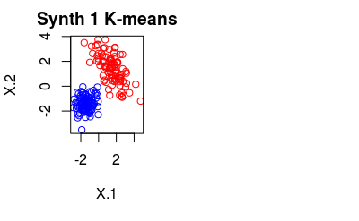

```r
par(mfrow=c(1,2))
X <- read.csv("/home/arnaud/Desktop/SY09P1/donnees/donnees/Synth1.csv", header=T, row.names=1)
z <- X[,3]
X <- X[,-3]
plot(X, col = c("red", "blue")[kmeans(X, 2)$cluster], main = "Synth 1 K-means")
plot(X, col = c("red", "blue")[adaptativeKmeans(X, 2)$cluster], main = "Synth 1 Adaptative K-means")
```

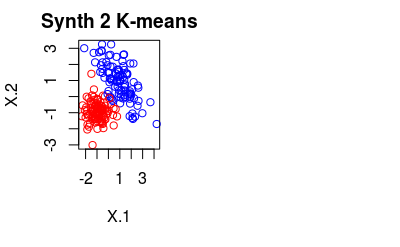

```r
par(mfrow=c(1,2))
X <- read.csv("/home/arnaud/Desktop/SY09P1/donnees/donnees/Synth2.csv", header=T, row.names=1)
z <- X[,3]
X <- X[,-3]
plot(X, col = c("red", "blue")[kmeans(X, 2)$cluster], main = "Synth 2 K-means")
plot(X, col = c("red", "blue")[adaptativeKmeans(X, 2, ness = 3, niter = 200)$cluster], main = "Synth 2 Adaptative K-means")
```

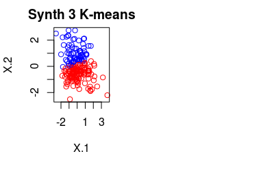

```r
par(mfrow=c(1,2))
X <- read.csv("/home/arnaud/Desktop/SY09P1/donnees/donnees/Synth3.csv", header=T, row.names=1)
z <- X[,3]
X <- X[,-3]
plot(X, col = c("red", "blue")[kmeans(X, 2)$cluster], main = "Synth 3 K-means")
plot(X, col = c("red", "blue")[adaptativeKmeans(X, 2)$cluster], main = "Synth 3 Adaptative K-means")
```

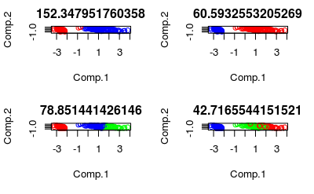

```r
par(mfrow=c(2,2))
data(iris)
X <- iris[,1:4]
z <- iris[,5]

ACPIris <- princomp(X)
for (i in c(2:3)) {
  km <- kmeans(X, i)
  plot(ACPIris$scores[,1:2], col = c("red", "blue", "green", "black", "orange")[km$cluster])
  title(toString(km$tot.withinss))

  akm <- adaptativeKmeans(X, i)
  plot(ACPIris$scores[,1:2], col = c("red", "blue", "green", "black", "orange")[akm$cluster])
  title(akm$J)
}
```

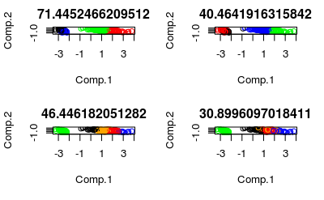

```r
par(mfrow=c(2,2))
for (i in c(4:5)) {
  km <- kmeans(X, i)
  plot(ACPIris$scores[,1:2], col = c("red", "blue", "green", "black", "orange")[km$cluster])
  title(toString(km$tot.withinss))

  akm <- adaptativeKmeans(X, i, ness = 1)
  plot(ACPIris$scores[,1:2], col = c("red", "blue", "green", "black", "orange")[akm$cluster])
  title(akm$J)
}
```

> A noter que plus on augmente le nombre de classes, plus il y a un risque que l’algorithme n’arrive pas a inverser certaines matrices et crash. Cela est du au fait que des classes plus petites se retrouvent parfois avec une seul valeure, ce que R semble avoir du mal à accepter

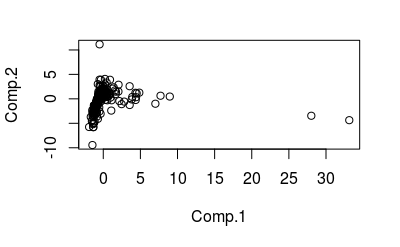

```r
Spam <- read.csv("/home/arnaud/Desktop/SY09P1/donnees/donnees/spam.csv", header=T, row.names=1)
X <- Spam[,-58]
z <- Spam[,58]
X <- scale(X)
X <- X[sample(c(1:dim(X)[1]), size = 300, replace = FALSE),]
ACPSpam <- princomp(X)
plot(ACPSpam$scores[,1:2])
```

> L’ACP classique ne va pas permettre de visualiser correctement les différends groupes.

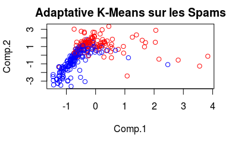

```r
spamPlot <- ACPSpam$scores[,1:2]
spamPlot <- spamPlot - colMeans(spamPlot)
dist <- spamPlot[,1] * spamPlot[,1] + spamPlot[,2] * spamPlot[,2]
dist <- matrix(dist, ncol = 1)
spamPlot <- as.matrix(spamPlot)
spamPlot <- cbind(spamPlot, dist)
indexesToRemove <- order(spamPlot[,3],decreasing = TRUE)[1:30]
indexesToRemove <- - indexesToRemove
spamPlot <- spamPlot[indexesToRemove,]
XAdapted = X[indexesToRemove,]
plot(spamPlot, col = c("red", "blue")[adaptativeKmeans(ACPSpam$scores[indexesToRemove,1:20], 2, ness = 3)$cluster], main = "Adaptative K-Means sur les Spams")
```

> On commence par calculer la moyenne des deux premiers composants de l’ACP, puis on centre ces deux composants. Ensuite, on enlève les valeurs extrèmes pour mieux visualiser le graphique.

> On applique l’algorithme directement sur le retour de l’ACP défaite des ses valeurs que l’on sait extrême. On applique l’algorithme les n premiers composants de l’ACP, En effet, passé un certain stade, les valeurs sont si petites qu’elles sont confondues avec 0. La matrice n’est plus définie posititve et l’algorithme crash. Une valeur de 20 permet dejà d’expliquer une bonne partie de la varaince.

> Il est compliqué de travailler sur ce Dataset puisque de nombreux facteurs entrent en jeux, certains rendant la matrice colinéaire et empêchant le bon déroulement de AdaptativeKmMean. On pourrait essayer de ne garder que les composantes a haute variance pour faire l’ACP.